# Single-Layer Networks - Part1

### Lecture Date: 2025-02-05

# PyTorch Setup for Neural Networks

```python
# Core Boilerplate Imports for PyTorch/Lightning
import numpy as np
import torch
import lightning.pytorch as pl
from torchinfo import summary
from torchview import draw_graph
import torchmetrics
import matplotlib.pyplot as plt
```

```python
print("GPU is present:",torch.cuda.is_available())
```

```
GPU is present: False
```

# Standard data set preparations

1. Create matrix of feature vectors (all but last column)
2. Create vector of class labels (last column only)

```python
data = np.loadtxt("https://jupyterhub.cs.mtsu.edu/azuread/services/csci4850-materials/public/WDBC.txt")
```

```python
data.shape
```

```
(568, 31)
```

```python
X = data[:,:-1]
X.shape
```

```
(568, 30)
```

```python
Y = data[:,-1:]
Y.shape
```

```
(568, 1)
```

### Integer Representation

```python
Y[0:5]
```

```
array([[1.],
       [1.],
       [0.],
       [0.],
       [0.]])
```

```python
X[0:5]
```

```
array([[0.6766275 , 0.6260183 , 0.6472149 , 0.4302279 , 0.5525704 ,
        0.3491604 , 0.343955  , 0.4110835 , 0.6424342 , 0.5776888 ,
        0.1912635 , 0.1358444 , 0.13899   , 0.1063261 , 0.1243816 ,
        0.1360414 , 0.09368687, 0.2273158 , 0.248765  , 0.1118298 ,
        0.681465  , 0.6138474 , 0.6086783 , 0.3815233 , 0.5610961 ,
        0.3030246 , 0.4596645 , 0.6721649 , 0.5959626 , 0.4476145 ],
       [0.5186766 , 0.5481161 , 0.5167639 , 0.2578169 , 0.6450428 ,
        0.5408222 , 0.33388   , 0.4365308 , 0.7407895 , 0.7105911 ,
        0.08858336, 0.2012692 , 0.09599636, 0.03882331, 0.1430132 ,
        0.2256278 , 0.06770202, 0.2561091 , 0.1841672 , 0.1243633 ,
        0.4889012 , 0.6703674 , 0.4872611 , 0.2108369 , 0.6850854 ,
        0.6278828 , 0.4424121 , 0.9281787 , 0.6423622 , 0.6144578 ],
       [0.5190324 , 0.5773931 , 0.5113528 , 0.2627349 , 0.5185435 ,
        0.3850608 , 0.2410965 , 0.1856859 , 0.4782895 , 0.6308498 ,
        0.07845458, 0.2268168 , 0.1011829 , 0.03603836, 0.1362673 ,
        0.3426145 , 0.1661111 , 0.3042243 , 0.2074731 , 0.1476542 ,
        0.4295228 , 0.5504643 , 0.4215764 , 0.172426  , 0.4609164 ,
        0.2997164 , 0.292492  , 0.3797251 , 0.3401627 , 0.3857349 ],
       [0.4087513 , 0.3714358 , 0.3925199 , 0.1618952 , 0.6401469 ,
        0.2382166 , 0.1243674 , 0.09786282, 0.5851974 , 0.6746716 ,
        0.07079708, 0.2386899 , 0.07129208, 0.02644781, 0.1592355 ,
        0.15613   , 0.1049495 , 0.1522637 , 0.2334389 , 0.1211126 ,
        0.3440622 , 0.442067  , 0.3265924 , 0.1099201 , 0.6073675 ,
        0.1899811 , 0.2073482 , 0.2553608 , 0.4430551 , 0.4424096 ],
       [0.3728211 , 0.5056008 , 0.3539523 , 0.135026  , 0.6548348 ,
        0.172872  , 0.1131912 , 0.1525845 , 0.5713816 , 0.6609195 ,
        0.1294466 , 0.5346981 , 0.1145132 , 0.04282553, 0.5152586 ,
        0.1023634 , 0.04709596, 0.214624  , 0.4402787 , 0.1193029 ,
        0.318535  , 0.594671  , 0.2933121 , 0.09468735, 0.680593  ,
        0.09697543, 0.09432907, 0.2314777 , 0.4343176 , 0.3733976 ]])
```

### One-hot Representation

```python
np.eye(len(np.unique(Y)))[Y[0:5,-1].astype(int)]
```

```
array([[0., 1.],
       [0., 1.],
       [1., 0.],
       [1., 0.],
       [1., 0.]])
```

The above vectors are *probability distributions*, and correspond to the targets for a network with 2 output units. However, most functions in PyTorch accept integer representations for targets to **save memory** even though the math is performed in the same way *as-if* one-hot representations were being provided.

# Neural Network - Input Layer Only

```python
# Define model - Input Layer ONLY
class NeuralNetwork(pl.LightningModule):
    def __init__(self, **kwargs):
        super().__init__(**kwargs)

    def forward(self, x):
        y = x
        return y

model = NeuralNetwork()
print(model)
```

```
NeuralNetwork()
```

Passing data into the network (and getting back the result).

```python
model(torch.tensor(X[0:5]).to(torch.float32))
```

```
tensor([[0.6766, 0.6260, 0.6472, 0.4302, 0.5526, 0.3492, 0.3440, 0.4111, 0.6424,
         0.5777, 0.1913, 0.1358, 0.1390, 0.1063, 0.1244, 0.1360, 0.0937, 0.2273,
         0.2488, 0.1118, 0.6815, 0.6138, 0.6087, 0.3815, 0.5611, 0.3030, 0.4597,
         0.6722, 0.5960, 0.4476],
        [0.5187, 0.5481, 0.5168, 0.2578, 0.6450, 0.5408, 0.3339, 0.4365, 0.7408,
         0.7106, 0.0886, 0.2013, 0.0960, 0.0388, 0.1430, 0.2256, 0.0677, 0.2561,
         0.1842, 0.1244, 0.4889, 0.6704, 0.4873, 0.2108, 0.6851, 0.6279, 0.4424,
         0.9282, 0.6424, 0.6145],
        [0.5190, 0.5774, 0.5114, 0.2627, 0.5185, 0.3851, 0.2411, 0.1857, 0.4783,
         0.6308, 0.0785, 0.2268, 0.1012, 0.0360, 0.1363, 0.3426, 0.1661, 0.3042,
         0.2075, 0.1477, 0.4295, 0.5505, 0.4216, 0.1724, 0.4609, 0.2997, 0.2925,
         0.3797, 0.3402, 0.3857],
        [0.4088, 0.3714, 0.3925, 0.1619, 0.6401, 0.2382, 0.1244, 0.0979, 0.5852,
         0.6747, 0.0708, 0.2387, 0.0713, 0.0264, 0.1592, 0.1561, 0.1049, 0.1523,
         0.2334, 0.1211, 0.3441, 0.4421, 0.3266, 0.1099, 0.6074, 0.1900, 0.2073,
         0.2554, 0.4431, 0.4424],
        [0.3728, 0.5056, 0.3540, 0.1350, 0.6548, 0.1729, 0.1132, 0.1526, 0.5714,
         0.6609, 0.1294, 0.5347, 0.1145, 0.0428, 0.5153, 0.1024, 0.0471, 0.2146,
         0.4403, 0.1193, 0.3185, 0.5947, 0.2933, 0.0947, 0.6806, 0.0970, 0.0943,
         0.2315, 0.4343, 0.3734]])
```

# Net Visualization/Summaries

```python
model_graph = draw_graph(model,
                         input_size=X[0:5].shape,
                         depth=2)
model_graph.visual_graph
```

[figure not shown]

```python
summary(model, input_size=X[0:5].shape)
```

```
==========================================================================================
Layer (type:depth-idx)                   Output Shape              Param #
==========================================================================================
NeuralNetwork                            [5, 30]                   --
==========================================================================================
Total params: 0
Trainable params: 0
Non-trainable params: 0
Total mult-adds (Units.MEGABYTES): 0
==========================================================================================
Input size (MB): 0.00
Forward/backward pass size (MB): 0.00
Params size (MB): 0.00
Estimated Total Size (MB): 0.00
==========================================================================================
```

# Add Single Layer (Output Layer)

### Sigmoid Activation Function

```python
# Define model
class NeuralNetwork(pl.LightningModule):
    def __init__(self, **kwargs):
        super().__init__(**kwargs)
        self.net_input = torch.nn.Linear(30,1)
        self.activation = torch.nn.Sigmoid()
        self.b_acc = torchmetrics.classification.Accuracy(task='binary')
        self.bce_loss = torch.nn.BCELoss()

    def forward(self, x):
        y = x
        y = self.net_input(y)
        y = self.activation(y)
        return y

    def configure_optimizers(self):
        optimizer = torch.optim.SGD(self.parameters(), lr=10.0)
        return optimizer

    def predict_step(self, pred_batch, batch_idx):
        x, y_true = pred_batch
        y_pred = self(x)
        return y_pred, y_true

    def training_step(self, train_batch, batch_idx):
        x, y_true = train_batch
        y_pred = self(x)
        acc = self.b_acc(y_pred,y_true)
        loss = self.bce_loss(y_pred,y_true)
        self.log('train_acc', acc, on_step=False, on_epoch=True)
        self.log('train_loss', loss, on_step=False, on_epoch=True)
        return loss

model = NeuralNetwork()
print(model)
```

```
NeuralNetwork(
  (net_input): Linear(in_features=30, out_features=1, bias=True)
  (activation): Sigmoid()
  (b_acc): BinaryAccuracy()
  (bce_loss): BCELoss()
)
```

```python
model(torch.tensor(X[0:5]).to(torch.float32)).detach().numpy()
```

```
array([[0.41610467],
       [0.4064115 ],
       [0.42620978],
       [0.4156934 ],
       [0.4304376 ]], dtype=float32)
```

```python
summary(model, input_size=X[0:5].shape)
```

```
==========================================================================================
Layer (type:depth-idx)                   Output Shape              Param #
==========================================================================================
NeuralNetwork                            [5, 1]                    --
├─Linear: 1-1                            [5, 1]                    31
├─Sigmoid: 1-2                           [5, 1]                    --
==========================================================================================
Total params: 31
Trainable params: 31
Non-trainable params: 0
Total mult-adds (Units.MEGABYTES): 0.00
==========================================================================================
Input size (MB): 0.00
Forward/backward pass size (MB): 0.00
Params size (MB): 0.00
Estimated Total Size (MB): 0.00
==========================================================================================
```

```python
model_graph = draw_graph(model,
                         input_size=X[0:5].shape,
                         depth=1)
model_graph.visual_graph
```

[figure not shown]

```python
Y.shape
```

```
(568, 1)
```

```python
Y[0:5]
```

```
array([[1.],
       [1.],
       [0.],
       [0.],
       [0.]])
```

```python
model(torch.tensor(X[0:5]).to(torch.float32).to(model.device)).cpu().detach().numpy()
```

```
array([[0.41610467],
       [0.4064115 ],
       [0.42620978],
       [0.4156934 ],
       [0.4304376 ]], dtype=float32)
```

```python
np.round(model(torch.tensor(X[0:5]).to(torch.float32).to(model.device)).cpu().detach().numpy())
```

```
array([[0.],
       [0.],
       [0.],
       [0.],
       [0.]], dtype=float32)
```

# Evaluation Metrics

```python
len(np.unique(Y))
```

```
2
```

```python
binary_accuracy = torchmetrics.classification.Accuracy(task='binary')
```

```python
y_pred = model(torch.tensor(X[0:5]).to(torch.float32).to(model.device)).cpu()
y_true = torch.tensor(Y[0:5]).to(torch.float32)
```

```python
y_pred
```

```
tensor([[0.4161],
        [0.4064],
        [0.4262],
        [0.4157],
        [0.4304]], grad_fn=<SigmoidBackward0>)
```

```python
torch.round(y_pred)
```

```
tensor([[0.],
        [0.],
        [0.],
        [0.],
        [0.]], grad_fn=<RoundBackward0>)
```

```python
y_true
```

```
tensor([[1.],
        [1.],
        [0.],
        [0.],
        [0.]])
```

```python
binary_accuracy(y_pred,y_true)
```

```
tensor(0.6000)
```

### Loss - How uncertain is the net?

```python
torch.nn.functional.binary_cross_entropy(y_pred,y_true)
```

```
tensor(0.6866, grad_fn=<BinaryCrossEntropyBackward0>)
```

```python
torch.nn.functional.binary_cross_entropy(y_pred,y_true,
                                         reduction="none")
```

```
tensor([[0.8768],
        [0.9004],
        [0.5555],
        [0.5373],
        [0.5629]], grad_fn=<BinaryCrossEntropyBackward0>)
```

```python
model.bce_loss(y_pred,y_true)
```

```
tensor(0.6866, grad_fn=<BinaryCrossEntropyBackward0>)
```

```python
# Notice this interesting case...
model.bce_loss(y_true,y_true)
```

```
tensor(0.)
```

### Helper Sympy Methods

```python
import sympy as sp

# Use sympy for differentiation of our activation
# functions and error function
x = sp.symbols('x')
y = sp.symbols('y')

# Tanh Activation Function - Vectorized g(x)
g = (sp.exp(2*x)-1)/(sp.exp(2*x)+1)
tanh = np.vectorize(lambda x: np.float32(g.evalf(subs=dict(x=x))))

# First Derivative of Tanh - Vectorized dg(x)/dx
dgdx = g.diff(x)
dtanh = np.vectorize(lambda x: np.float32(dgdx.evalf(subs=dict(x=x))))

# Sigmoid Activation Function - Vectorized f(x)
f = 1 / (sp.exp(-x)+1)
sigmoid = np.vectorize(lambda x: np.float32(f.evalf(subs=dict(x=x))))

# First Derivative of Tanh - Vectorized dg(x)/dx
dfdx = f.diff(x)
dsigmoid = np.vectorize(lambda x: np.float32(dfdx.evalf(subs=dict(x=x))))

# Binary Cross-entropy Error (and first derivative)
b = -((y*sp.log(x)+(1-y)*sp.log(1-x)))
dbdx = b.diff(x)

# Vectorized forms of BCE and dBCE(x)/x
bce = np.vectorize(lambda x,y: np.float32(b.evalf(subs=dict(x=x,y=y))))
dbce = np.vectorize(lambda x,y: np.float32(dbdx.evalf(subs=dict(x=x,y=y))))
```

```python
bce(y_pred.detach().numpy(),y_true)
```

```
array([[0.8768184 ],
       [0.9003891 ],
       [0.5554914 ],
       [0.53732944],
       [0.5628869 ]], dtype=float32)
```

```python
bce(y_pred.detach().numpy(),y_true).mean()
```

```
0.68658304
```

# Numpy Equivalent

## Forward-pass

```python
weights = [p.cpu().detach().numpy() for p in model.parameters()]
len(weights)
```

```
2
```

```python
weights
```

```
[array([[-0.13776019,  0.07460377,  0.08674555, -0.12050229, -0.10460122,
         -0.09879351, -0.02142869,  0.14831884,  0.073485  , -0.15542677,
          0.11240355,  0.09426398,  0.09124824, -0.172512  , -0.02260611,
         -0.05075356,  0.11033443, -0.02453536, -0.09593147,  0.04610078,
         -0.11402039,  0.153224  ,  0.12121978,  0.08948138, -0.10455885,
          0.13893543, -0.12002571, -0.13434577, -0.01438984, -0.16650866]],
       dtype=float32),
 array([-0.09941127], dtype=float32)]
```

```python
weights[0].shape
```

```
(1, 30)
```

```python
weights[1].shape
```

```
(1,)
```

```python
net_inputs = (X[0:5] @ weights[0].T) + weights[1]
net_inputs
```

```
array([[-0.33878479],
       [-0.37881999],
       [-0.29733206],
       [-0.34047801],
       [-0.28006599]])
```

```python
activations = sigmoid(net_inputs)
activations
```

```
array([[0.4161047 ],
       [0.40641153],
       [0.4262098 ],
       [0.41569337],
       [0.4304376 ]], dtype=float32)
```

### Matches PyTorch (to reasonable precision)

```python
y_pred
```

```
tensor([[0.4161],
        [0.4064],
        [0.4262],
        [0.4157],
        [0.4304]], grad_fn=<SigmoidBackward0>)
```

```python
binary_accuracy(torch.tensor(activations).to(torch.float32),
                     y_true)
```

```
tensor(0.6000)
```

```python
model.bce_loss(torch.tensor(activations).to(torch.float32),
               y_true)
```

```
tensor(0.6866)
```

### Matches PyTorch (to reasonable precision)

```python
loss = model.bce_loss(model(torch.tensor(X[0:5]).to(torch.float32).to(model.device)).cpu(),
                      y_true)
loss
```

```
tensor(0.6866, grad_fn=<BinaryCrossEntropyBackward0>)
```

## Backward Pass

```python
eta = 10.0
```

```python
loss_np = bce(activations,y_true.detach().numpy()).mean()
loss_np
```

```
0.68658304
```

```python
loss
```

```
tensor(0.6866, grad_fn=<BinaryCrossEntropyBackward0>)
```

```python
loss.backward()
```

```python
output_deltas = dbce(activations,Y[0:5])*dsigmoid(net_inputs)/5.0
sp.Matrix(output_deltas)
```

$\displaystyle \left[\begin{matrix}-0.116779\\-0.118718\\0.085242\\0.0831387\\0.0860875\end{matrix}\right]$

```python
# Numpy gradients - input_to_output
input_to_output_grads = (output_deltas.T @ X[0:5])
sp.Matrix(input_to_output_grads)
```

$\displaystyle \left[\begin{array}{cccccccccccccccccccccccccccccc}-0.0302703845458761 & -0.0145521857798502 & -0.030236987053027 & -0.0333691908094034 & 0.0126890902326748 & -0.0374693137900338 & -0.0391685739662141 & -0.0627298349931055 & -0.0243559836340405 & 0.0149414078340262 & -0.00913464840085402 & 0.0454515068956904 & -0.00321727207625747 & -0.00806811510594636 & 0.0377082912056893 & 0.00832498568956256 & 0.00796128064036705 & 0.000117719669821117 & 0.0240812684934415 & 0.00510246265977472 & -0.0449819316360235 & -0.0163997188060701 & -0.0405884205025665 & -0.037596059261721 & 0.00151967874429599 & -0.0602361590109458 & -0.0559095273038047 & -0.115159803203615 & -0.0426352331459656 & -0.023411990712329\end{array}\right]$

Matches PyTorch gradients...

```python
# PyTorch gradients - input_to_output
sp.Matrix(model.net_input.weight.grad.cpu().detach().numpy())
```

$\displaystyle \left[\begin{array}{cccccccccccccccccccccccccccccc}-0.0302704 & -0.0145522 & -0.030237 & -0.0333692 & 0.0126891 & -0.0374693 & -0.0391686 & -0.0627299 & -0.024356 & 0.0149414 & -0.00913465 & 0.0454515 & -0.00321728 & -0.00806812 & 0.0377083 & 0.00832498 & 0.00796128 & 0.000117714 & 0.0240813 & 0.00510246 & -0.0449819 & -0.0163997 & -0.0405884 & -0.0375961 & 0.00151967 & -0.0602362 & -0.0559095 & -0.11516 & -0.0426353 & -0.023412\end{array}\right]$

```python
# Numpy gradients - output_bias
output_bias_grads = np.sum(output_deltas,0)
sp.Matrix(output_bias_grads)
```

$\displaystyle \left[\begin{matrix}0.0189714\end{matrix}\right]$

Matches PyTorch gradients...

```python
# PyTorch gradients - output_bias
sp.Matrix(model.net_input.bias.grad.cpu().detach().numpy())
```

$\displaystyle \left[\begin{matrix}0.0189714\end{matrix}\right]$

```python
weights
```

```
[array([[-0.13776019,  0.07460377,  0.08674555, -0.12050229, -0.10460122,
         -0.09879351, -0.02142869,  0.14831884,  0.073485  , -0.15542677,
          0.11240355,  0.09426398,  0.09124824, -0.172512  , -0.02260611,
         -0.05075356,  0.11033443, -0.02453536, -0.09593147,  0.04610078,
         -0.11402039,  0.153224  ,  0.12121978,  0.08948138, -0.10455885,
          0.13893543, -0.12002571, -0.13434577, -0.01438984, -0.16650866]],
       dtype=float32),
 array([-0.09941127], dtype=float32)]
```

```python
# Apply weight updates - will confirm -after- PyTorch SGD
new_weights = [weights[0] + -eta*input_to_output_grads,
               weights[1] + -eta*output_bias_grads,
              ]
new_weights
```

```
[array([[ 0.16494365,  0.22012562,  0.38911542,  0.21318962, -0.23149212,
          0.27589963,  0.37025705,  0.77561719,  0.31704484, -0.30484085,
          0.20375003, -0.36025109,  0.12342096, -0.09183084, -0.39968902,
         -0.13400341,  0.03072163, -0.02571256, -0.33674416, -0.00492385,
          0.33579892,  0.31722119,  0.52710398,  0.46544197, -0.11975564,
          0.74129702,  0.43906956,  1.01725226,  0.41196249,  0.06761125]]),
 array([-0.28912532], dtype=float32)]
```

# PyTorch Lightning Way

Data Loaders, Loggers, and Trainers - oh my! **I'll discuss these details more below.** For now, just know that this is how PyTorch Lightning can be used to perform the same weight update computations (stochastic gradient descent) as I did with numpy above.

```python
xy_train = torch.utils.data.DataLoader(list(zip(torch.tensor(X[0:5]).to(torch.float32),
                                                torch.tensor(Y[0:5]).to(torch.float32))),
                                       shuffle=False, batch_size=5)
```

```python
logger = pl.loggers.CSVLogger("logs",
                              name="Demo-2025-02-06")
trainer = pl.Trainer(logger=logger,
                     max_epochs=1,
                     enable_progress_bar=True,
                     log_every_n_steps=0,
                     callbacks=[pl.callbacks.TQDMProgressBar(refresh_rate=20)])
```

```
GPU available: False, used: False
TPU available: False, using: 0 TPU cores
HPU available: False, using: 0 HPUs
```

## Trainer can be used to make predictions for entire data sets...

```python
trainer.predict(model,dataloaders=xy_train)
```

```
/opt/conda/lib/python3.12/site-packages/lightning/pytorch/trainer/connectors/data_connector.py:425: The 'predict_dataloader' does not have many workers which may be a bottleneck. Consider increasing the value of the `num_workers` argument` to `num_workers=31` in the `DataLoader` to improve performan…
```

```
Predicting: |          | 0/? [00:00<?, ?it/s]
```

```
[(tensor([[0.4161],
          [0.4064],
          [0.4262],
          [0.4157],
          [0.4304]]),
  tensor([[1.],
          [1.],
          [0.],
          [0.],
          [0.]]))]
```

```python
activations
```

```
array([[0.4161047 ],
       [0.40641153],
       [0.4262098 ],
       [0.41569337],
       [0.4304376 ]], dtype=float32)
```

## Of course, it's also used for updating network weights/parameters

```python
trainer.fit(model, xy_train)
```

```
  | Name       | Type           | Params | Mode
------------------------------------------------------
0 | net_input  | Linear         | 31     | train
1 | activation | Sigmoid        | 0      | train
2 | b_acc      | BinaryAccuracy | 0      | train
3 | bce_loss   | BCELoss        | 0      | train
------------------------------------------------------
31        Trainable params
0         Non-trainable params
31        Total params
0.000     Total estimated model params size (MB)
4         Modules in train mode
0         Modules in eval mode
/opt/conda/lib/python3.12/site-packages/lightning/pytorch/trainer/connectors/data_connector.py:425: The 'train_dataloader' does not have many workers which may be a bottleneck. Consider increasing the value of the `num_workers` argument` to `num_workers=31` in the `DataLoader` to improve performance…
```

```
Training: |          | 0/? [00:00<?, ?it/s]
```

```
`Trainer.fit` stopped: `max_epochs=1` reached.
```

```python
# PyTorch New Weights
[p.detach().numpy() for p in model.parameters()]
```

```
[array([[ 0.16494381,  0.22012575,  0.38911548,  0.21318974, -0.23149186,
          0.2758998 ,  0.37025717,  0.77561736,  0.31704473, -0.30484062,
          0.20375009, -0.3602511 ,  0.12342101, -0.09183084, -0.39968902,
         -0.1340034 ,  0.03072166, -0.0257125 , -0.3367441 , -0.00492384,
          0.33579907,  0.31722134,  0.527104  ,  0.46544215, -0.11975557,
          0.74129707,  0.43906963,  1.0172527 ,  0.4119627 ,  0.06761131]],
       dtype=float32),
 array([-0.2891251], dtype=float32)]
```

### Numpy/Sympy *matches* PyTorch weight updates...

```python
new_weights
```

```
[array([[ 0.16494365,  0.22012562,  0.38911542,  0.21318962, -0.23149212,
          0.27589963,  0.37025705,  0.77561719,  0.31704484, -0.30484085,
          0.20375003, -0.36025109,  0.12342096, -0.09183084, -0.39968902,
         -0.13400341,  0.03072163, -0.02571256, -0.33674416, -0.00492385,
          0.33579892,  0.31722119,  0.52710398,  0.46544197, -0.11975564,
          0.74129702,  0.43906956,  1.01725226,  0.41196249,  0.06761125]]),
 array([-0.28912532], dtype=float32)]
```

# PyTorch Lightning (Complete Pipeline)

Complete Training Regime for WDBC (for *Binary Classification*)

The code below implements:

1. a **single-layer neural network** with a single sigmoid unit output layer
2. two **data loaders** for creating a training data set (80%) and validation data set (20%)
3. a **trainer and logger** for executing the training/validation (and prediction) process
4. the use of matplotlib to plot the resulting **training/validation loss and accuracy curves**

```python
# (Re)define model - duplicated from above
class NeuralNetwork(pl.LightningModule):
    def __init__(self, **kwargs):
        super().__init__(**kwargs)
        self.net_input = torch.nn.Linear(30,1)
        self.activation = torch.nn.Sigmoid()
        self.b_acc = torchmetrics.classification.Accuracy(task='binary')
        self.bce_loss = torch.nn.BCELoss()

    def forward(self, x):
        y = x
        y = self.net_input(y)
        y = self.activation(y)
        return y

    def configure_optimizers(self):
        optimizer = torch.optim.SGD(self.parameters(), lr=0.1)
        return optimizer

    def predict_step(self, pred_batch, batch_idx):
        x, y_true = pred_batch
        y_pred = self(x)
        return y_pred, y_true

    def training_step(self, train_batch, batch_idx):
        x, y_true = train_batch
        y_pred = self(x)
        acc = self.b_acc(y_pred,y_true)
        loss = self.bce_loss(y_pred,y_true)
        self.log('train_acc', acc, on_step=False, on_epoch=True)
        self.log('train_loss', loss, on_step=False, on_epoch=True)
        return loss

    def validation_step(self, val_batch, batch_idx):
        x, y_true = val_batch
        y_pred = self(x)
        acc = self.b_acc(y_pred,y_true)
        loss = self.bce_loss(y_pred,y_true)
        self.log('val_acc', acc, on_step=False, on_epoch=True)
        self.log('val_loss', loss, on_step=False, on_epoch=True)
        return loss

model = NeuralNetwork()
print(model)
```

```
NeuralNetwork(
  (net_input): Linear(in_features=30, out_features=1, bias=True)
  (activation): Sigmoid()
  (b_acc): BinaryAccuracy()
  (bce_loss): BCELoss()
)
```

# Data Loader Preparation

Data loaders wrap a data set to provide mechanisms for easily iterating over batches of feature vectors (and associated targets), and reshuffling for each epoch. While we *could* write custom code to iterate over the data ourselves, we instead utilize `DataLoader` since it will save use from having to write this custom (really more boilerplate) code. This prevents bugs, saves time, and keeps our own code more concise and readable (once we understand what functionality it provides).

A typical rule-of-thumb for setting up training and validation data is to:

1. shuffle all rows in the data set
2. use the top rows (80%) of the data for *training*
3. use the bottom rows (20%) of the data for *validation*

This 80%/20% rule is just something often works well in practice. Information theoretic methods for calculating "optimal" splits for generalization purposes have been introduced in the field, but are not widely adopted because (most of the time) the calculated values are often close to 80%/20%. When they are not, it is typically because the data set has particular properties where we would already be able to guess that the 80%/20% rule is not appropriate (for example, a small data set where one class is not very common - might lead to none of these uncommon examples being in the validation data resulting in biased performance).

```python
# What's our data again - WDBC here
data_url = "https://jupyterhub.cs.mtsu.edu/azuread/services/csci4850-materials/public/WDBC.txt"

# How much should be validation data? (80%/20% rule)
val_split = 0.2
rng = np.random.default_rng() # Random number generator for shuffling the data
data = np.loadtxt(data_url) # Read the data
rng.shuffle(data) # Shuffle the rows in the data matrix
split_point = int(data.shape[0]*(1.0-val_split)) # Which index should we split at? (80% down)

# Actually split the data into two piles - and also split feature vectors and targets
data_train = list(zip(torch.tensor(data[:split_point,:-1]).to(torch.float32),
                  torch.tensor(data[:split_point,-1:]).to(torch.float32)))
data_val = list(zip(torch.tensor(data[split_point:,:-1]).to(torch.float32),
                    torch.tensor(data[split_point:,-1:]).to(torch.float32)))

# Finally, we wrap the feature vector/target pairs into DataLoaders
# Here we pick a batch size - the loaders will provide this many vectors each iteration
batch_size = 32
xy_train = torch.utils.data.DataLoader(data_train,
                                       batch_size=batch_size,
                                       num_workers=4, # This can be tuned for performance, but 4 usually is fine for assignments
                                       shuffle=True) # We shuffle training data every epoch
xy_val = torch.utils.data.DataLoader(data_val,
                                     batch_size=batch_size,
                                     num_workers=4, # This can be tuned for performance, but 4 usually is fine for assignments
                                     shuffle=False) # We -do not- shuffle validation data every epoch

# The num_workers argument is used to control how many parallel threads are used when iterating through the data (can be tuned for performance or memory concerns)
```

### How do we use a `DataLoader`?

Data loaders provide iterators over a data set. We might have split our data set into training/validation, but during the training process we muct shuffle our training data and break it into groups of `batch_size` (32 above) feature vector/target pairs. The data loader let's us do that.

```python
# Grab an iterator from our loader
train_iter = iter(xy_train)

# Grab the first batch
a_batch = next(train_iter)

print("Items in the batch list:", len(a_batch))
print("Shape of first item in the list (feature vectors):",a_batch[0].shape)
print("Shape of second item in the list (target vectors):",a_batch[1].shape)
print()
print("Feature vectors:")
print(a_batch[0])
print("Target vectors:")
print(a_batch[1])
print()

# Let's grab a single vector-target pair just for completeness:
print("The first pair in the batch:")
print("Features:", a_batch[0][0], "| Targets:", a_batch[1][0])
```

```
Items in the batch list: 2
Shape of first item in the list (feature vectors): torch.Size([32, 30])
Shape of second item in the list (target vectors): torch.Size([32, 1])

Feature vectors:
tensor([[0.6197, 0.6507, 0.6074, 0.3790, 0.6157, 0.3318, 0.3941, 0.3279, 0.4303,
         0.6020, 0.1843, 0.3412, 0.1714, 0.1079, 1.0000, 0.6318, 0.3631, 0.7439,
         0.2755, 0.4209, 0.5014, 0.5666, 0.4793, 0.2400, 0.5584, 0.1695, 0.2239,
         0.3777, 0.2415, 0.3286],
        [0.4422, 0.4328, 0.4170, 0.1908, 0.4625, 0.1000, 0.0314, 0.0844, 0.4842,
         0.5707, 0.1315, 0.4504, 0.1131, 0.0575, 0.2363, 0.0797, 0.0251, 0.2122,
         0.4348, 0.0992, 0.3579, 0.4080, 0.3255, 0.1213, 0.3778, 0.0445, 0.0179,
         0.0973, 0.2864, 0.2859],
        [0.5187, 0.5481, 0.5168, 0.2578, 0.6450, 0.5408, 0.3339, 0.4365, 0.7408,
         0.7106, 0.0886, 0.2013, 0.0960, 0.0388, 0.1430, 0.2256, 0.0677, 0.2561,
         0.1842, 0.1244, 0.4889, 0.6704, 0.4873, 0.2108, 0.6851, 0.6279, 0.4424,
         0.9282, 0.6424, 0.6145],
        [0.6097, 0.4175, 0.6154, 0.3649, 0.7258, 0.6589, 0.5223, 0.6963, 1.0000,
         0.7608, 0.3641, 0.1998, 0.3310, 0.2055, 0.2579, 0.2806, 0.0942, 0.4541,
         0.2923, 0.2495, 0.6174, 0.4320, 0.6067, 0.3434, 0.6941, 0.3733, 0.3077,
         0.8763, 0.6125, 0.5104],
        [0.5069, 0.5639, 0.5115, 0.2582, 0.6420, 0.5814, 0.5002, 0.4301, 0.6411,
         0.7484, 0.2449, 0.2596, 0.2444, 0.1121, 0.3022, 0.5211, 0.1742, 0.3501,
         0.2153, 0.2049, 0.4903, 0.5957, 0.4741, 0.2256, 0.7367, 0.5905, 0.5529,
         0.6134, 0.4284, 0.5455],
        [0.5443, 0.6433, 0.5432, 0.2928, 0.6622, 0.4913, 0.3943, 0.4349, 0.6336,
         0.6712, 0.1528, 0.2072, 0.1591, 0.0802, 0.1681, 0.2258, 0.0903, 0.2052,
         0.2239, 0.0994, 0.5624, 0.7410, 0.5943, 0.2983, 0.7372, 0.5775, 0.5060,
         0.6955, 0.6067, 0.4760],
        [0.3458, 0.4638, 0.3222, 0.1152, 0.4253, 0.0679, 0.0000, 0.0000, 0.5437,
         0.6616, 0.1232, 1.0000, 0.1015, 0.0400, 0.0550, 0.0497, 0.0000, 0.0000,
         0.4812, 0.0566, 0.2766, 0.4205, 0.2478, 0.0714, 0.3197, 0.0258, 0.0000,
         0.0000, 0.2876, 0.3161],
        [0.4625, 0.5290, 0.4430, 0.2077, 0.6946, 0.2197, 0.0735, 0.1315, 0.8355,
         0.6247, 0.1463, 0.2706, 0.1307, 0.0641, 0.2254, 0.0843, 0.0492, 0.2184,
         0.3738, 0.0514, 0.3929, 0.4867, 0.3615, 0.1450, 0.5827, 0.1044, 0.0648,
         0.2164, 0.4815, 0.3101],
        [0.5699, 0.5916, 0.5448, 0.3190, 0.5022, 0.1931, 0.0773, 0.1652, 0.5026,
         0.5847, 0.1321, 0.2430, 0.1122, 0.0747, 0.1294, 0.0685, 0.0278, 0.1438,
         0.1849, 0.1019, 0.5325, 0.6839, 0.4928, 0.2703, 0.5305, 0.1466, 0.1165,
```

[output cut: 117 more lines]

```
        [0.],
        [0.],
        [1.],
        [0.],
        [0.],
        [0.],
        [1.],
        [1.],
        [1.]])

The first pair in the batch:
Features: tensor([0.6197, 0.6507, 0.6074, 0.3790, 0.6157, 0.3318, 0.3941, 0.3279, 0.4303,
        0.6020, 0.1843, 0.3412, 0.1714, 0.1079, 1.0000, 0.6318, 0.3631, 0.7439,
        0.2755, 0.4209, 0.5014, 0.5666, 0.4793, 0.2400, 0.5584, 0.1695, 0.2239,
        0.3777, 0.2415, 0.3286]) | Targets: tensor([1.])
```

```python
# Reinitialize the iterator and check shapes
train_iter = iter(xy_train)
for i, a_batch in enumerate(train_iter):
    print("Batch number:",i)
    print("Shape of first item in the list (feature vectors):",a_batch[0].shape)
    print("Shape of second item in the list (target vectors):",a_batch[1].shape)
```

```
Batch number: 0
Shape of first item in the list (feature vectors): torch.Size([32, 30])
Shape of second item in the list (target vectors): torch.Size([32, 1])
Batch number: 1
Shape of first item in the list (feature vectors): torch.Size([32, 30])
Shape of second item in the list (target vectors): torch.Size([32, 1])
Batch number: 2
Shape of first item in the list (feature vectors): torch.Size([32, 30])
Shape of second item in the list (target vectors): torch.Size([32, 1])
Batch number: 3
Shape of first item in the list (feature vectors): torch.Size([32, 30])
Shape of second item in the list (target vectors): torch.Size([32, 1])
Batch number: 4
Shape of first item in the list (feature vectors): torch.Size([32, 30])
Shape of second item in the list (target vectors): torch.Size([32, 1])
Batch number: 5
Shape of first item in the list (feature vectors): torch.Size([32, 30])
Shape of second item in the list (target vectors): torch.Size([32, 1])
Batch number: 6
Shape of first item in the list (feature vectors): torch.Size([32, 30])
Shape of second item in the list (target vectors): torch.Size([32, 1])
Batch number: 7
Shape of first item in the list (feature vectors): torch.Size([32, 30])
Shape of second item in the list (target vectors): torch.Size([32, 1])
Batch number: 8
Shape of first item in the list (feature vectors): torch.Size([32, 30])
Shape of second item in the list (target vectors): torch.Size([32, 1])
Batch number: 9
Shape of first item in the list (feature vectors): torch.Size([32, 30])
Shape of second item in the list (target vectors): torch.Size([32, 1])
Batch number: 10
Shape of first item in the list (feature vectors): torch.Size([32, 30])
Shape of second item in the list (target vectors): torch.Size([32, 1])
Batch number: 11
Shape of first item in the list (feature vectors): torch.Size([32, 30])
Shape of second item in the list (target vectors): torch.Size([32, 1])
Batch number: 12
Shape of first item in the list (feature vectors): torch.Size([32, 30])
Shape of second item in the list (target vectors): torch.Size([32, 1])
Batch number: 13
Shape of first item in the list (feature vectors): torch.Size([32, 30])
Shape of second item in the list (target vectors): torch.Size([32, 1])
Batch number: 14
Shape of first item in the list (feature vectors): torch.Size([6, 30])
Shape of second item in the list (target vectors): torch.Size([6, 1])
```

```python
# 14 batches of 32 and a final batch of 6
14*32 + 6
```

```
454
```

```python
# Confirm how many items we kept for the training data (using 80%/20% split)
split_point
```

```
454
```

```python
class BinaryClassificationDataModule(pl.LightningDataModule):
    def __init__(self,
                 data_url = "https://jupyterhub.cs.mtsu.edu/azuread/services/csci4850-materials/public/WDBC.txt",
                 batch_size = 32,
                 val_split = 0.2,
                 num_workers = 4,
                 **kwargs):
        super().__init__(**kwargs)
        self.data_url = data_url
        self.batch_size = batch_size
        self.val_split = val_split
        self.num_workers = num_workers
        self.data_train = None
        self.data_val = None

    def setup(self, stage: str):
        if (stage == 'fit' or \
            stage == 'validate' or \
            stage == 'predict') and \
            not(self.data_train and self.data_val):
            rng = np.random.default_rng()
            data = np.loadtxt(self.data_url)
            rng.shuffle(data)
            split_point = int(data.shape[0]*(1.0-self.val_split))
            self.data_train = list(zip(torch.tensor(data[:split_point,:-1]).to(torch.float32),
                                       torch.tensor(data[:split_point,-1:]).to(torch.float32)))
            self.data_val = list(zip(torch.tensor(data[split_point:,:-1]).to(torch.float32),
                                     torch.tensor(data[split_point:,-1:]).to(torch.float32)))

    def train_dataloader(self):
        return torch.utils.data.DataLoader(self.data_train,
                                           batch_size=self.batch_size,
                                           num_workers=self.num_workers,
                                           shuffle=True)

    def val_dataloader(self):
        return torch.utils.data.DataLoader(self.data_val,
                                           batch_size=self.batch_size,
                                           num_workers=self.num_workers,
                                           shuffle=False)

    def predict_dataloader(self):
        return torch.utils.data.DataLoader(self.data_val,
                                           batch_size=self.batch_size,
                                           num_workers=self.num_workers,
                                           shuffle=False)
```

```python
wdbc_datamodule = BinaryClassificationDataModule()
```

Let's explore this object for a moment, but keep in mind that we normally would *not use the datamodule like this directly*. Instead, the `setup` and `train_dataloader` functions will be called by the `Trainer` when they are needed.

```python
wdbc_datamodule.setup('fit')
xy_train = wdbc_datamodule.train_dataloader()
xy_val = wdbc_datamodule.val_dataloader()
```

```python
batch = next(iter(xy_train))
batch
```

```
[tensor([[0.5286, 0.4313, 0.5034, 0.2694, 0.5461, 0.2048, 0.0784, 0.1430, 0.5174,
          0.5853, 0.1054, 0.1368, 0.0733, 0.0441, 0.1849, 0.1230, 0.0369, 0.1569,
          0.1965, 0.0727, 0.4526, 0.4146, 0.4072, 0.1828, 0.5472, 0.1465, 0.0974,
          0.2739, 0.3804, 0.3290],
         [0.3523, 0.4598, 0.3427, 0.1209, 0.5936, 0.3746, 0.3062, 0.1847, 0.5490,
          0.8329, 0.1501, 0.4628, 0.1425, 0.0507, 0.4131, 0.6505, 0.3023, 0.4660,
          0.4915, 0.6005, 0.3124, 0.4923, 0.2909, 0.0917, 0.5845, 0.2788, 0.2784,
          0.3405, 0.3938, 0.5600],
         [0.4682, 0.5229, 0.4459, 0.2154, 0.4489, 0.1527, 0.0422, 0.0624, 0.5635,
          0.6043, 0.1127, 0.3015, 0.1058, 0.0481, 0.2506, 0.1516, 0.0339, 0.1054,
          0.2642, 0.0905, 0.4023, 0.5745, 0.3793, 0.1524, 0.5022, 0.1556, 0.0615,
          0.1442, 0.4048, 0.3580],
         [0.4642, 0.4733, 0.4514, 0.2047, 0.6622, 0.3775, 0.2250, 0.2785, 0.6694,
          0.6672, 0.1081, 0.3091, 0.1178, 0.0398, 0.2508, 0.2904, 0.1291, 0.3554,
          0.3623, 0.1915, 0.3937, 0.5016, 0.3751, 0.1390, 0.6033, 0.2512, 0.2055,
          0.4323, 0.4690, 0.4008],
         [0.4248, 0.5285, 0.4131, 0.1763, 0.5266, 0.2927, 0.1540, 0.1884, 0.5224,
          0.6944, 0.0954, 0.2845, 0.1455, 0.0404, 0.2158, 0.3808, 0.1108, 0.3093,
          0.2371, 0.2686, 0.3674, 0.5509, 0.3670, 0.1284, 0.5013, 0.2659, 0.1889,
          0.3969, 0.3713, 0.4810],
         [0.3661, 0.7029, 0.3484, 0.1285, 0.5526, 0.2217, 0.1406, 0.1361, 0.5240,
          0.6288, 0.0765, 0.4583, 0.0654, 0.0267, 0.3871, 0.2021, 0.1213, 0.3260,
          0.2334, 0.1655, 0.3008, 0.7047, 0.2770, 0.0841, 0.6217, 0.1616, 0.1597,
          0.3136, 0.3353, 0.3992],
         [0.4166, 0.4376, 0.3962, 0.1681, 0.5982, 0.1778, 0.0892, 0.1610, 0.4987,
          0.6255, 0.0853, 0.1567, 0.0793, 0.0329, 0.2218, 0.0643, 0.0499, 0.2245,
          0.2403, 0.0560, 0.3610, 0.4318, 0.3361, 0.1226, 0.5943, 0.0983, 0.1215,
          0.3777, 0.3875, 0.3420],
         [0.3058, 0.4735, 0.2869, 0.0884, 0.6573, 0.1693, 0.0000, 0.0000, 0.7115,
          0.7552, 0.1172, 0.5685, 0.1011, 0.0328, 0.6666, 0.1036, 0.0000, 0.0000,
          0.7785, 0.2286, 0.2484, 0.4530, 0.2255, 0.0564, 0.6051, 0.0734, 0.0000,
          0.0000, 0.4733, 0.3911],
         [0.4031, 0.3605, 0.3808, 0.1586, 0.5740, 0.1121, 0.0035, 0.0166, 0.6428,
          0.5974, 0.0827, 0.2620, 0.0712, 0.0315, 0.2707, 0.0665, 0.0038, 0.0631,
          0.2987, 0.0545, 0.3385, 0.3833, 0.3080, 0.1077, 0.5656, 0.0695, 0.0040,
          0.0382, 0.4155, 0.3078],
         [0.4859, 0.4870, 0.4746, 0.2300, 0.5543, 0.3321, 0.2263, 0.2392, 0.6079,
          0.6343, 0.0781, 0.1832, 0.0821, 0.0357, 0.1279, 0.2075, 0.0927, 0.2413,
          0.2003, 0.1326, 0.4201, 0.5147, 0.4037, 0.1666, 0.5153, 0.2993, 0.2923,
          0.4835, 0.4134, 0.4260],
```

[output cut: 105 more lines]

```
         [0.],
         [1.],
         [0.],
         [0.],
         [0.],
         [1.],
         [1.],
         [1.],
         [0.],
         [0.],
         [1.],
         [1.],
         [0.],
         [1.],
         [0.]])]
```

```python
type(batch)
```

```
list
```

```python
len(batch)
```

```
2
```

# PyTorch Lightning

### Loggers and Trainers

The `Trainer` will provide the functionality needed to iterate over the training batches, calculate the loss values and derivatives, and then update the weights accordingly. It also provides a way to iterate over the validation data to check for **generalization** while the training process is underway. The documentation shows the general scaffold for how trainers operate, but keep in mind that it does do a few other things as well: https://lightning.ai/docs/pytorch/stable/common/trainer.html#under-the-hood

The `Logger` provides the trainer with an interface for collecting performance measure statistics that we are calculating during the training process. We will be utilizing comma separated value (CSV) files (a text-only spreadsheet format), but there are other loggers which can write to web-based platforms in the cloud for managing and accessing this data. For now, we will access our CSV files after the training process is complete, and create **learning curves** from the collected data. While we won't be using other loggers in the course, they can be easily integrated by choosing the appropriate logger class. Here is more information on the possible logger options: https://lightning.ai/docs/pytorch/stable/api_references.html#loggers

```python
logger = pl.loggers.CSVLogger("logs",name="wdbc_single_layer",)
trainer = pl.Trainer(max_epochs=100,logger=logger,
                     enable_progress_bar=True,
                     log_every_n_steps=0,
                     callbacks=[pl.callbacks.TQDMProgressBar(refresh_rate=20)])
```

```
GPU available: False, used: False
TPU available: False, using: 0 TPU cores
HPU available: False, using: 0 HPUs
```

```python
result = trainer.validate(model, xy_val)
```

```
Validation: |          | 0/? [00:00<?, ?it/s]
```

```
┏━━━━━━━━━━━━━━━━━━━━━━━━━━━┳━━━━━━━━━━━━━━━━━━━━━━━━━━━┓
┃      Validate metric      ┃       DataLoader 0        ┃
┡━━━━━━━━━━━━━━━━━━━━━━━━━━━╇━━━━━━━━━━━━━━━━━━━━━━━━━━━┩
│          val_acc          │    0.3947368562221527     │
│         val_loss          │    0.6788285374641418     │
└───────────────────────────┴───────────────────────────┘
```

```python
result
```

```
[{'val_acc': 0.3947368562221527, 'val_loss': 0.6788285374641418}]
```

```python
result[0]['val_loss']
```

```
0.6788285374641418
```

```python
result[0]['val_acc']
```

```
0.3947368562221527
```

```python
result = trainer.fit(model,
                     train_dataloaders=xy_train,
                     val_dataloaders=xy_val)
```

```
  | Name       | Type           | Params | Mode
------------------------------------------------------
0 | net_input  | Linear         | 31     | train
1 | activation | Sigmoid        | 0      | train
2 | b_acc      | BinaryAccuracy | 0      | train
3 | bce_loss   | BCELoss        | 0      | train
------------------------------------------------------
31        Trainable params
0         Non-trainable params
31        Total params
0.000     Total estimated model params size (MB)
4         Modules in train mode
0         Modules in eval mode
```

```
Sanity Checking: |          | 0/? [00:00<?, ?it/s]
```

```
Training: |          | 0/? [00:00<?, ?it/s]
```

```
Validation: |          | 0/? [00:00<?, ?it/s]
```

```
Validation: |          | 0/? [00:00<?, ?it/s]
```

```
Validation: |          | 0/? [00:00<?, ?it/s]
```

```
Validation: |          | 0/? [00:00<?, ?it/s]
```

```
Validation: |          | 0/? [00:00<?, ?it/s]
```

```
Validation: |          | 0/? [00:00<?, ?it/s]
```

```
Validation: |          | 0/? [00:00<?, ?it/s]
```

```
Validation: |          | 0/? [00:00<?, ?it/s]
```

```
Validation: |          | 0/? [00:00<?, ?it/s]
```

```
Validation: |          | 0/? [00:00<?, ?it/s]
```

```
Validation: |          | 0/? [00:00<?, ?it/s]
```

```
Validation: |          | 0/? [00:00<?, ?it/s]
```

```
Validation: |          | 0/? [00:00<?, ?it/s]
```

```
Validation: |          | 0/? [00:00<?, ?it/s]
```

```
Validation: |          | 0/? [00:00<?, ?it/s]
```

```
Validation: |          | 0/? [00:00<?, ?it/s]
```

```
Validation: |          | 0/? [00:00<?, ?it/s]
```

```
Validation: |          | 0/? [00:00<?, ?it/s]
```

```
Validation: |          | 0/? [00:00<?, ?it/s]
```

```
Validation: |          | 0/? [00:00<?, ?it/s]
```

```
Validation: |          | 0/? [00:00<?, ?it/s]
```

```
Validation: |          | 0/? [00:00<?, ?it/s]
```

```
Validation: |          | 0/? [00:00<?, ?it/s]
```

```
Validation: |          | 0/? [00:00<?, ?it/s]
```

```
Validation: |          | 0/? [00:00<?, ?it/s]
```

```
Validation: |          | 0/? [00:00<?, ?it/s]
```

```
Validation: |          | 0/? [00:00<?, ?it/s]
```

```
Validation: |          | 0/? [00:00<?, ?it/s]
```

```
Validation: |          | 0/? [00:00<?, ?it/s]
```

```
Validation: |          | 0/? [00:00<?, ?it/s]
```

```
Validation: |          | 0/? [00:00<?, ?it/s]
```

```
Validation: |          | 0/? [00:00<?, ?it/s]
```

```
Validation: |          | 0/? [00:00<?, ?it/s]
```

```
Validation: |          | 0/? [00:00<?, ?it/s]
```

```
Validation: |          | 0/? [00:00<?, ?it/s]
```

```
Validation: |          | 0/? [00:00<?, ?it/s]
```

```
Validation: |          | 0/? [00:00<?, ?it/s]
```

```
Validation: |          | 0/? [00:00<?, ?it/s]
```

```
Validation: |          | 0/? [00:00<?, ?it/s]
```

```
Validation: |          | 0/? [00:00<?, ?it/s]
```

```
Validation: |          | 0/? [00:00<?, ?it/s]
```

```
Validation: |          | 0/? [00:00<?, ?it/s]
```

```
Validation: |          | 0/? [00:00<?, ?it/s]
```

```
Validation: |          | 0/? [00:00<?, ?it/s]
```

```
Validation: |          | 0/? [00:00<?, ?it/s]
```

```
Validation: |          | 0/? [00:00<?, ?it/s]
```

```
Validation: |          | 0/? [00:00<?, ?it/s]
```

```
Validation: |          | 0/? [00:00<?, ?it/s]
```

```
Validation: |          | 0/? [00:00<?, ?it/s]
```

```
Validation: |          | 0/? [00:00<?, ?it/s]
```

```
Validation: |          | 0/? [00:00<?, ?it/s]
```

```
Validation: |          | 0/? [00:00<?, ?it/s]
```

```
Validation: |          | 0/? [00:00<?, ?it/s]
```

```
Validation: |          | 0/? [00:00<?, ?it/s]
```

```
Validation: |          | 0/? [00:00<?, ?it/s]
```

```
Validation: |          | 0/? [00:00<?, ?it/s]
```

```
Validation: |          | 0/? [00:00<?, ?it/s]
```

```
Validation: |          | 0/? [00:00<?, ?it/s]
```

```
Validation: |          | 0/? [00:00<?, ?it/s]
```

```
Validation: |          | 0/? [00:00<?, ?it/s]
```

```
Validation: |          | 0/? [00:00<?, ?it/s]
```

```
Validation: |          | 0/? [00:00<?, ?it/s]
```

```
Validation: |          | 0/? [00:00<?, ?it/s]
```

```
Validation: |          | 0/? [00:00<?, ?it/s]
```

```
Validation: |          | 0/? [00:00<?, ?it/s]
```

```
Validation: |          | 0/? [00:00<?, ?it/s]
```

```
Validation: |          | 0/? [00:00<?, ?it/s]
```

```
Validation: |          | 0/? [00:00<?, ?it/s]
```

```
Validation: |          | 0/? [00:00<?, ?it/s]
```

```
Validation: |          | 0/? [00:00<?, ?it/s]
```

```
Validation: |          | 0/? [00:00<?, ?it/s]
```

```
Validation: |          | 0/? [00:00<?, ?it/s]
```

```
Validation: |          | 0/? [00:00<?, ?it/s]
```

```
Validation: |          | 0/? [00:00<?, ?it/s]
```

```
Validation: |          | 0/? [00:00<?, ?it/s]
```

```
Validation: |          | 0/? [00:00<?, ?it/s]
```

```
Validation: |          | 0/? [00:00<?, ?it/s]
```

```
Validation: |          | 0/? [00:00<?, ?it/s]
```

```
Validation: |          | 0/? [00:00<?, ?it/s]
```

```
Validation: |          | 0/? [00:00<?, ?it/s]
```

```
Validation: |          | 0/? [00:00<?, ?it/s]
```

```
Validation: |          | 0/? [00:00<?, ?it/s]
```

```
Validation: |          | 0/? [00:00<?, ?it/s]
```

```
Validation: |          | 0/? [00:00<?, ?it/s]
```

```
Validation: |          | 0/? [00:00<?, ?it/s]
```

```
Validation: |          | 0/? [00:00<?, ?it/s]
```

```
Validation: |          | 0/? [00:00<?, ?it/s]
```

```
Validation: |          | 0/? [00:00<?, ?it/s]
```

```
Validation: |          | 0/? [00:00<?, ?it/s]
```

```
Validation: |          | 0/? [00:00<?, ?it/s]
```

```
Validation: |          | 0/? [00:00<?, ?it/s]
```

```
Validation: |          | 0/? [00:00<?, ?it/s]
```

```
Validation: |          | 0/? [00:00<?, ?it/s]
```

```
Validation: |          | 0/? [00:00<?, ?it/s]
```

```
Validation: |          | 0/? [00:00<?, ?it/s]
```

```
Validation: |          | 0/? [00:00<?, ?it/s]
```

```
Validation: |          | 0/? [00:00<?, ?it/s]
```

```
Validation: |          | 0/? [00:00<?, ?it/s]
```

```
Validation: |          | 0/? [00:00<?, ?it/s]
```

```
Validation: |          | 0/? [00:00<?, ?it/s]
```

```
`Trainer.fit` stopped: `max_epochs=100` reached.
```

```python
result = trainer.validate(model, xy_val)
```

```
Validation: |          | 0/? [00:00<?, ?it/s]
```

```
┏━━━━━━━━━━━━━━━━━━━━━━━━━━━┳━━━━━━━━━━━━━━━━━━━━━━━━━━━┓
┃      Validate metric      ┃       DataLoader 0        ┃
┡━━━━━━━━━━━━━━━━━━━━━━━━━━━╇━━━━━━━━━━━━━━━━━━━━━━━━━━━┩
│          val_acc          │    0.9035087823867798     │
│         val_loss          │    0.26455339789390564    │
└───────────────────────────┴───────────────────────────┘
```

```python
result
```

```
[{'val_acc': 0.9035087823867798, 'val_loss': 0.26455339789390564}]
```

```python
result[0]['val_acc']
```

```
0.9035087823867798
```

```python
trainer.predict(model, xy_val)
```

```
Predicting: |          | 0/? [00:00<?, ?it/s]
```

```
[(tensor([[0.0588],
          [0.0332],
          [0.9376],
          [0.0474],
          [0.9605],
          [0.9303],
          [0.0571],
          [0.4106],
          [0.1707],
          [0.8635],
          [0.5334],
          [0.8032],
          [0.2627],
          [0.0768],
          [0.9837],
          [0.1228],
          [0.0857],
          [0.4404],
          [0.3431],
          [0.4071],
          [0.1204],
          [0.7088],
          [0.2800],
          [0.6823],
          [0.0110],
          [0.0781],
          [0.9979],
          [0.2190],
          [0.6446],
          [0.2565],
          [0.1349],
          [0.1144]]),
  tensor([[0.],
          [0.],
          [1.],
          [0.],
          [1.],
          [1.],
          [0.],
          [0.],
```

[output cut: 173 more lines]

```
          [0.],
          [0.],
          [1.],
          [0.],
          [0.],
          [0.],
          [0.],
          [0.],
          [0.],
          [0.],
          [0.],
          [0.],
          [0.],
          [0.],
          [0.]]))]
```

# Plotting Learning Curves

```python
import pandas as pd
```

```python
results = pd.read_csv(logger.log_dir+"/metrics.csv",delimiter=',')
```

```python
results
```

|  | epoch | step | train_acc | train_loss | val_acc | val_loss |
| --- | --- | --- | --- | --- | --- | --- |
| 0 | 0 | 0 | NaN | NaN | 0.394737 | 0.678829 |
| 1 | 0 | 14 | NaN | NaN | 0.894737 | 0.635031 |
| 2 | 0 | 14 | 0.702643 | 0.651952 | NaN | NaN |
| 3 | 1 | 29 | NaN | NaN | 0.657895 | 0.604894 |
| 4 | 1 | 29 | 0.837004 | 0.613329 | NaN | NaN |
| ... | ... | ... | ... | ... | ... | ... |
| 197 | 98 | 1484 | NaN | NaN | 0.903509 | 0.265088 |
| 198 | 98 | 1484 | 0.944934 | 0.187180 | NaN | NaN |
| 199 | 99 | 1499 | NaN | NaN | 0.903509 | 0.264553 |
| 200 | 99 | 1499 | 0.947137 | 0.186681 | NaN | NaN |
| 201 | 100 | 1500 | NaN | NaN | 0.903509 | 0.264553 |

202 rows × 6 columns

```python
results['epoch']
```

```
0        0
1        0
2        0
3        1
4        1
      ...
197     98
198     98
199     99
200     99
201    100
Name: epoch, Length: 202, dtype: int64
```

```python
results['train_loss']
```

```
0           NaN
1           NaN
2      0.651952
3           NaN
4      0.613329
         ...
197         NaN
198    0.187180
199         NaN
200    0.186681
201         NaN
Name: train_loss, Length: 202, dtype: float64
```

```python
results['val_loss']
```

```
0      0.678829
1      0.635031
2           NaN
3      0.604894
4           NaN
         ...
197    0.265088
198         NaN
199    0.264553
200         NaN
201    0.264553
Name: val_loss, Length: 202, dtype: float64
```

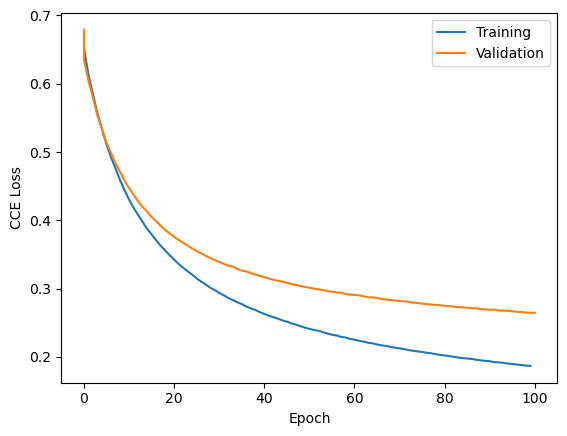

```python
plt.plot(results["epoch"][np.logical_not(np.isnan(results["train_loss"]))],
         results["train_loss"][np.logical_not(np.isnan(results["train_loss"]))],
         label="Training")
plt.plot(results["epoch"][np.logical_not(np.isnan(results["val_loss"]))],
         results["val_loss"][np.logical_not(np.isnan(results["val_loss"]))],
         label="Validation")
plt.legend()
plt.ylabel("CCE Loss")
plt.xlabel("Epoch")
plt.show()
```

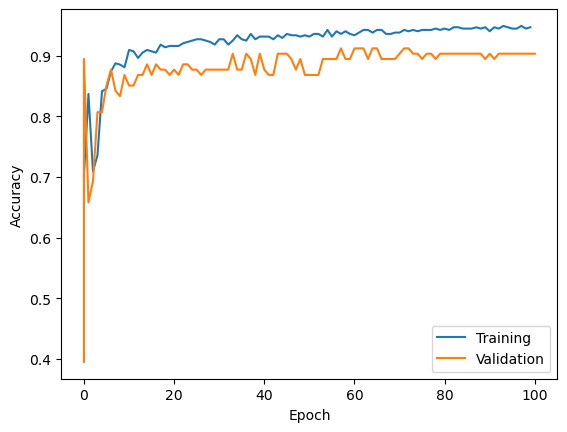

```python
plt.plot(results["epoch"][np.logical_not(np.isnan(results["train_acc"]))],
         results["train_acc"][np.logical_not(np.isnan(results["train_acc"]))],
         label="Training")
plt.plot(results["epoch"][np.logical_not(np.isnan(results["val_acc"]))],
         results["val_acc"][np.logical_not(np.isnan(results["val_acc"]))],
         label="Validation")
plt.legend()
plt.ylabel("Accuracy")
plt.xlabel("Epoch")
plt.show()
```

```python
val_pred = trainer.predict(model, xy_val)
```

```
Predicting: |          | 0/? [00:00<?, ?it/s]
```

```python
y_pred = np.round(torch.cat([x[0] for x in val_pred]).flatten().detach().numpy())
y_true = torch.cat([x[1] for x in val_pred]).flatten().detach().numpy()
```

```python
y_pred
```

```
array([0., 0., 1., 0., 1., 1., 0., 0., 0., 1., 1., 1., 0., 0., 1., 0., 0.,
       0., 0., 0., 0., 1., 0., 1., 0., 0., 1., 0., 1., 0., 0., 0., 1., 1.,
       1., 0., 0., 0., 1., 0., 0., 1., 1., 0., 0., 0., 0., 0., 0., 0., 1.,
       0., 1., 0., 1., 1., 0., 0., 0., 1., 0., 1., 0., 1., 1., 0., 0., 1.,
       0., 1., 1., 0., 0., 0., 0., 0., 0., 0., 1., 0., 0., 1., 0., 1., 0.,
       0., 0., 1., 0., 0., 0., 1., 1., 0., 1., 1., 0., 1., 0., 0., 0., 1.,
       0., 0., 1., 0., 0., 0., 0., 0., 0., 0., 0., 0.], dtype=float32)
```

```python
y_true
```

```
array([0., 0., 1., 0., 1., 1., 0., 0., 0., 1., 1., 1., 1., 0., 1., 0., 0.,
       0., 1., 0., 0., 1., 0., 1., 0., 0., 1., 0., 0., 0., 1., 0., 1., 1.,
       1., 0., 1., 0., 1., 0., 0., 1., 1., 0., 0., 0., 1., 0., 0., 1., 1.,
       0., 1., 0., 1., 1., 0., 0., 0., 1., 0., 1., 0., 1., 1., 1., 0., 1.,
       0., 1., 0., 0., 0., 0., 0., 0., 0., 0., 1., 0., 0., 1., 0., 1., 0.,
       0., 0., 1., 0., 0., 0., 1., 1., 0., 1., 1., 0., 1., 1., 0., 0., 1.,
       0., 0., 0., 0., 0., 0., 0., 0., 0., 0., 0., 0.], dtype=float32)
```

```python
np.where(y_pred.astype(int) != y_true.astype(int))[0]
```

```
array([ 12,  18,  28,  30,  36,  46,  49,  65,  70,  98, 104])
```

```python
len(np.where(y_pred.astype(int) == y_true.astype(int))[0])
```

```
103
```

```python
y_pred.shape[0]
```

```
114
```

```python
len(np.where(y_pred.astype(int) == y_true.astype(int))[0]) / y_pred.shape[0]
```

```
0.9035087719298246
```

One final check...

```python
result = trainer.validate(model, xy_val)
```

```
Validation: |          | 0/? [00:00<?, ?it/s]
```

```
┏━━━━━━━━━━━━━━━━━━━━━━━━━━━┳━━━━━━━━━━━━━━━━━━━━━━━━━━━┓
┃      Validate metric      ┃       DataLoader 0        ┃
┡━━━━━━━━━━━━━━━━━━━━━━━━━━━╇━━━━━━━━━━━━━━━━━━━━━━━━━━━┩
│          val_acc          │    0.9035087823867798     │
│         val_loss          │    0.26455339789390564    │
└───────────────────────────┴───────────────────────────┘
```

```python
print(result[0]['val_acc'])
```

```
0.9035087823867798
```

Raw data reported every 10 epochs...

```python
print("Validation accuracy:",*["%.8f"%(x) for x in
                               results['val_acc'][np.logical_not(np.isnan(results["val_acc"]))][0::10]])
```

```
Validation accuracy: 0.39473686 0.86842108 0.86842108 0.87719297 0.90350878 0.86842108 0.89473683 0.89473683 0.90350878 0.89473683 0.90350878
```